# Влияние модераторов и типов курса на посещение форума. Выживаемость

## Содержание отчета

1. Связь между типом курса и средним посещением форума на курсе
2. Связь между выживаемостью на курсе и средним посещением форума на курсе
3. Связь между нормализованной активностью студентов и нормализованной активностью модераторов на форуме;
4. Связь между выживаемостью на курсе и нормализованной активностью студентов и модераторов;

## 0. Описание

### Описание баз данных

- **students** - длинная база данных, с данными на уровне студентов
- **courses** - короткая база данных, с данными на уровне курсов

### Описание переменных

- **Тип задания** - бинарные переменные; сообщают есть ли такой тип задания на курсе;
  - *is_prog* - есть ли задание по программированию;
  - *is_math* - есть ли задание по математике;
  - *is_peer* - есть ли пир-ревью;
- **Метрики форума**
  - *student_vis_mean* - среднее посещение форума студентами на курсе;
  - *ans_learner* - абсолютное количество ответов студентов на курсе;
  - *q_learner* - абсолютное количество вопросов студентов на курсе;
  - *ans_learner_n* - количество ответов студентов на курсе / количество студентов на курсе;
  - *q_learner_n* - количество вопросов студентов на курсе / количество студентов на курсе;
- **Метрики активности модераторов**
  - *ans_staff* - абсолютное количество ответов модераторов на курсе;
  - *q_staff* - абсолютное количество вопросов модераторов на курсе;
  - *ans_staff_b* - отвечали ли модераторы на вопросы на курсе (1 от 10 ответов);
  - *q_staff_b* - задавали ли модераторы вопросы на курсе (1 от 10 вопросов);
  - *ans_staff_n* - (количество ответов модераторов / количество студентов) *100;
  - *q_staff_n* - (количество вопросов модераторов / количество студентов) * 100;
- **Метрика выживаемости**
  - *passing_rate* - прошедшие курс / записавшиеся на курс

### Как создавались бинарные переменные типов заданий

- К сожалению, не всегда удается автоматически определить какие на курсе задания, а потому приходится использовать разнообразные признаки для их кодирования.
- *is_prog*
  - есть ли в таблице course_items.csv задания со словом “programming”;
  - есть ли в таблице assessment_questions.csv вопросы с типом 14 (codeExpression)
- *is_math*
  - есть ли задания в таблице assessment_math_expression_questions.csv;
  - есть ли в таблице peer_assignment_submission_schema_parts.csv слова “math”,“calculate”, “Рассчитайте”
- *is_peer*
  - есть ли в таблице ‘course_items.csv’ задание с типом 104 (peer-review);

```
## Распределение курсов по типу заданий:
```

```
##   course_with yes no
## 1        prog  11 43
## 2        math  22 32
## 3        peer  30 24
```

## 1. Тип курса и среднее посещение

### 1.1 Описательная статистика

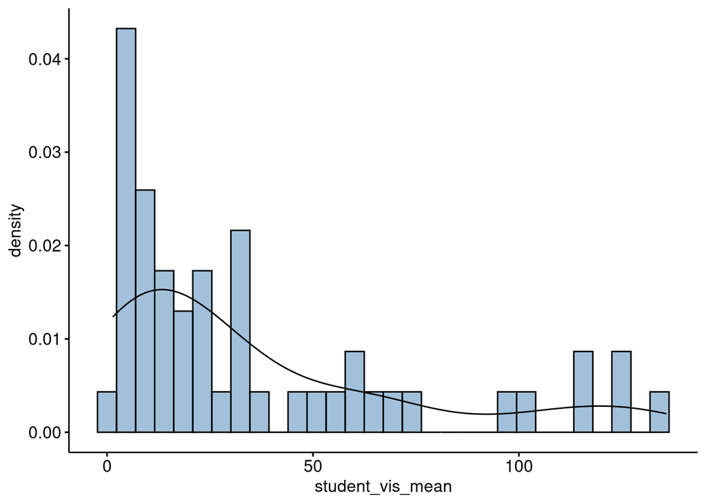

```r
gghistogram(courses, x = "student_vis_mean", y = "..density..",
            fill = "steelblue",bins = 30, add_density = TRUE)
```

```r
shapiro.test(courses$student_vis_mean)
```

```
##
##  Shapiro-Wilk normality test
##
## data:  courses$student_vis_mean
## W = 0.80346, p-value = 1.054e-06
```

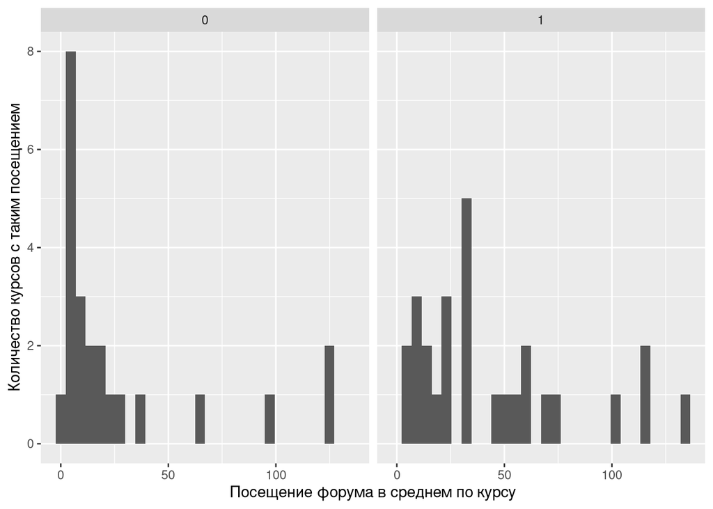

```r
courses %>%
  ggplot(aes(x = student_vis_mean)) + geom_histogram() + facet_wrap(~is_peer_b, labeller = labeller(yes = "1", no = "0")) + labs(x = "Посещение форума в среднем по курсу", y = "Количество курсов с таким посещением")
```

### 1.2 Mann-Whitney U tests в виде расчетов и с силой эффекта

#### Во всех трех случаях есть значимая разница в среднем посещении форума между курсами с разными типами заданий

```
##
##  Wilcoxon rank sum exact test
##
## data:  student_vis_mean by is_prog_b
## W = 99, p-value = 0.03011
## alternative hypothesis: true location shift is not equal to 0
```

```
## Effect size (r)
##       0.3053328
```

```
##
##  Wilcoxon rank sum exact test
##
## data:  student_vis_mean by is_math_b
## W = 164, p-value = 0.00846
## alternative hypothesis: true location shift is not equal to 0
```

```
## Effect size (r)
##       0.3688701
```

```
##
##  Wilcoxon rank sum exact test
##
## data:  student_vis_mean by is_peer_b
## W = 176, p-value = 0.00826
## alternative hypothesis: true location shift is not equal to 0
```

```
## Effect size (r)
##       0.3702517
```

### 1.3 Mann-Whitney U tests в виде графиков

#### На графиках указаны статистики теста и значимость различий между курсами с разными типами заданий

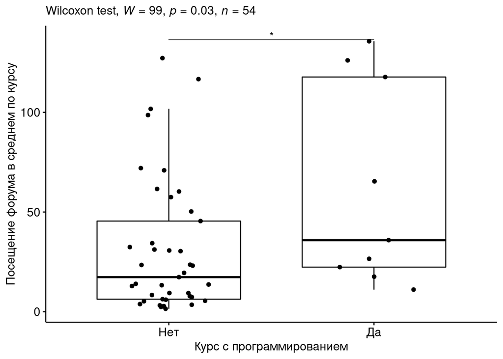

```r
stat.test <- courses %>%
  wilcox_test(student_vis_mean ~ is_prog_b) %>%
  add_significance()
bxp <- ggboxplot(
  courses, x = "is_prog_b", y = "student_vis_mean",
  ylab = "Посещение форума в среднем по курсу", xlab = "Курс с программированием", add = "jitter") +
scale_x_discrete(labels=c("Нет","Да"))
stat.test <- stat.test %>% add_xy_position(x = "group")
bxp +
  stat_pvalue_manual(stat.test, tip.length = 0) +
  labs(subtitle = get_test_label(stat.test, detailed = TRUE))
```

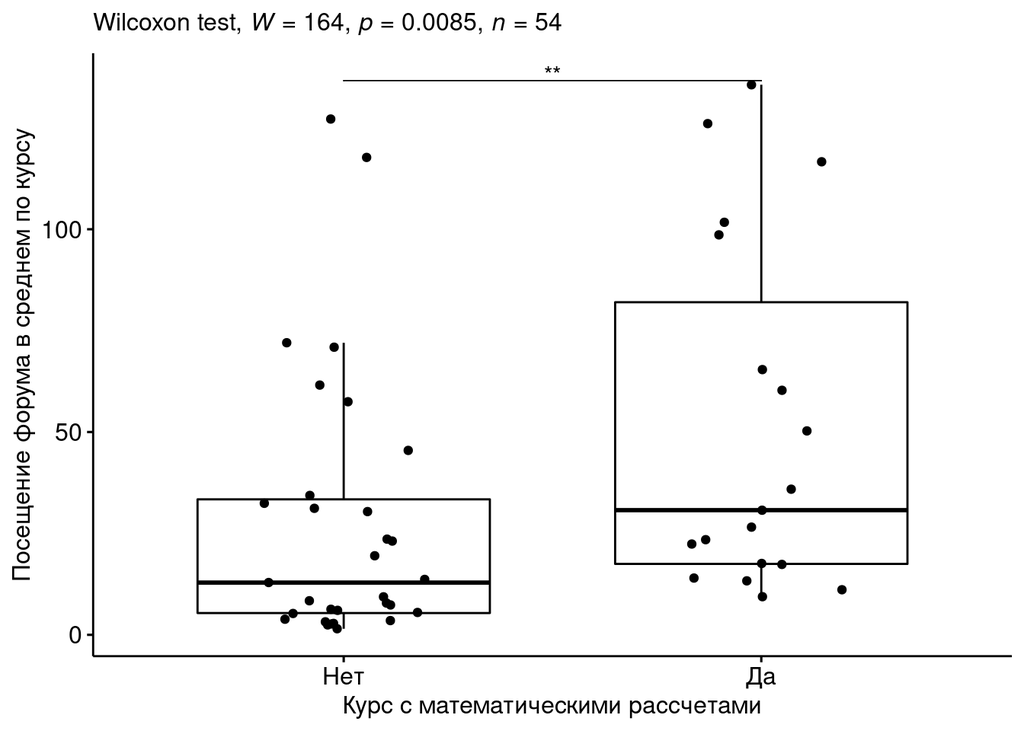

```r
stat.test <- courses %>%
  wilcox_test(student_vis_mean ~ is_math_b) %>%
  add_significance()
bxp <- ggboxplot(
  courses, x = "is_math_b", y = "student_vis_mean",
  ylab = "Посещение форума в среднем по курсу", xlab = "Курс с математическими рассчетами", add = "jitter") +
scale_x_discrete(labels=c("Нет","Да"))
stat.test <- stat.test %>% add_xy_position(x = "group")
bxp +
  stat_pvalue_manual(stat.test, tip.length = 0) +
  labs(subtitle = get_test_label(stat.test, detailed = TRUE))
```

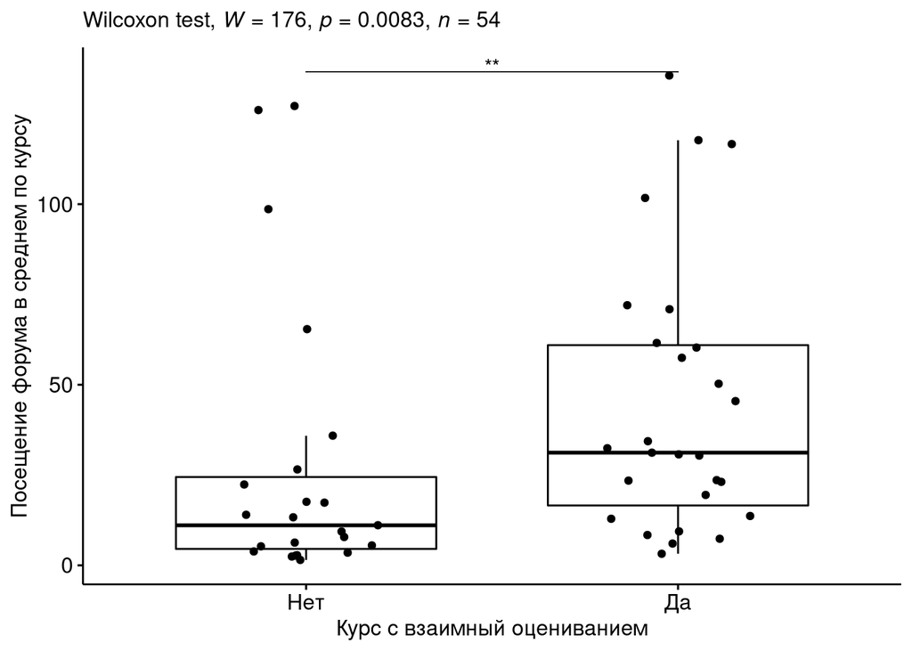

```r
stat.test <- courses %>%
  wilcox_test(student_vis_mean ~ is_peer_b) %>%
  add_significance()
bxp <- ggboxplot(
  courses, x = "is_peer_b", y = "student_vis_mean",
  ylab = "Посещение форума в среднем по курсу", xlab = "Курс с взаимный оцениванием", add = "jitter") +
scale_x_discrete(labels=c("Нет","Да"))
stat.test <- stat.test %>% add_xy_position(x = "group")
bxp +
  stat_pvalue_manual(stat.test, tip.length = 0) +
  labs(subtitle = get_test_label(stat.test, detailed = TRUE))
```

## 2. Посещение форума и выживаемость на курсе

### 2.1 Анализ распределения остатков

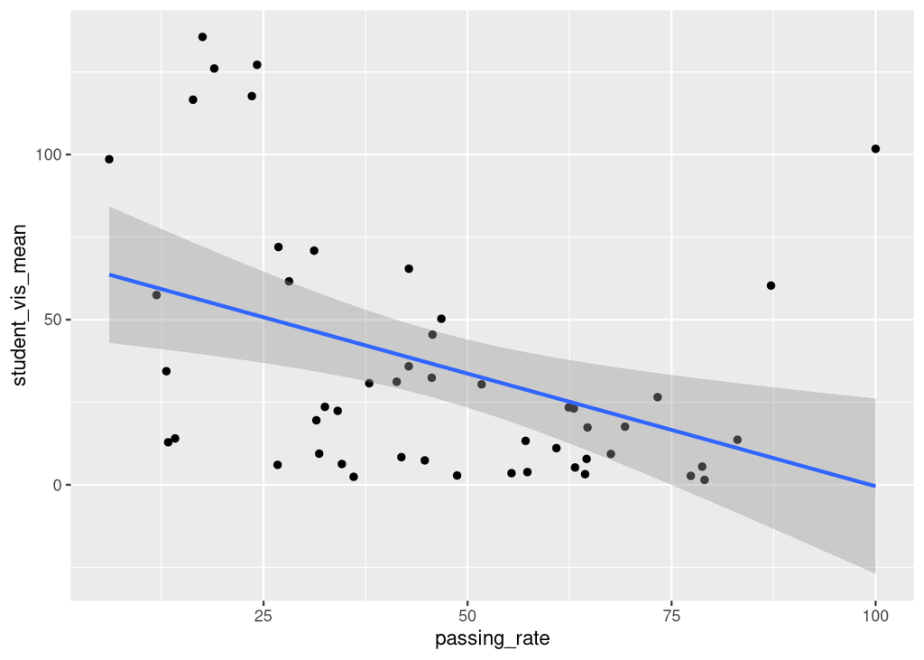

```r
courses %>%
  ggplot(aes(x = passing_rate, y = student_vis_mean)) + geom_point() +  geom_smooth(method = "lm")
```

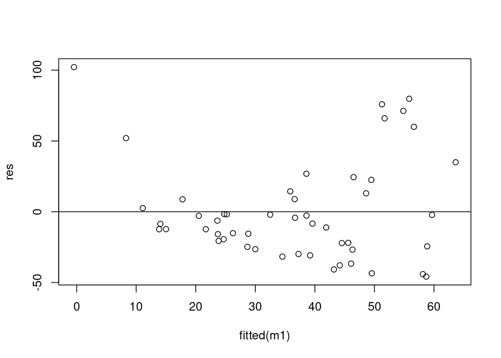

```r
m1 <-  lm((student_vis_mean) ~ passing_rate, courses)
res <- resid(m1)
plot(fitted(m1), res)
abline(0,0)
```

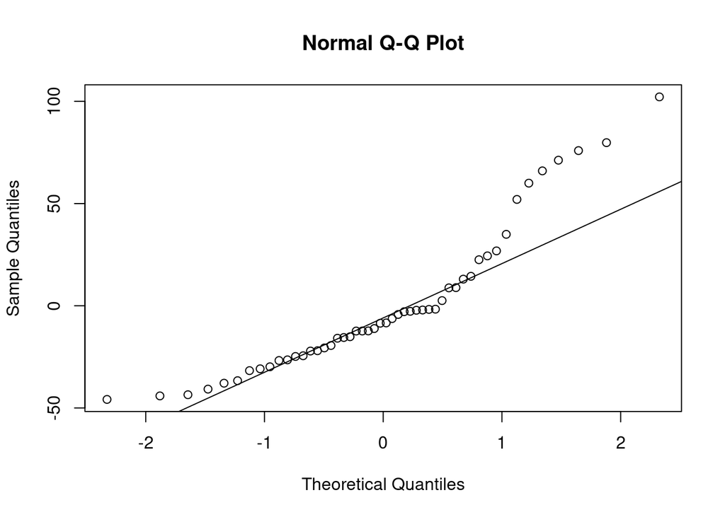

```
## Мы видим, что распределение остатков нельзя назвать нормальным поскольку большая часть значений student_vis_mean распределены близко к нулю.
## Поэтому мы трансформировали эту переменную с помощью функции log()
```

```r
qqnorm(res)
qqline(res)
```

```r
m1 <-  lm(log(student_vis_mean) ~ passing_rate, courses)
summary(m1)
```

```
##
## Call:
## lm(formula = log(student_vis_mean) ~ passing_rate, data = courses)
##
## Residuals:
##     Min      1Q  Median      3Q     Max
## -2.3108 -0.9904  0.2778  0.8153  2.8078
##
## Coefficients:
##               Estimate Std. Error t value Pr(>|t|)
## (Intercept)   3.966763   0.362550  10.941 1.23e-14 ***
## passing_rate -0.021522   0.007109  -3.027  0.00396 **
## ---
## Signif. codes:  0 '***' 0.001 '**' 0.01 '*' 0.05 '.' 0.1 ' ' 1
##
## Residual standard error: 1.125 on 48 degrees of freedom
##   (4 observations deleted due to missingness)
## Multiple R-squared:  0.1603, Adjusted R-squared:  0.1428
## F-statistic: 9.165 on 1 and 48 DF,  p-value: 0.00396
```

```
## Теперь остатки распределены более равномерно
```

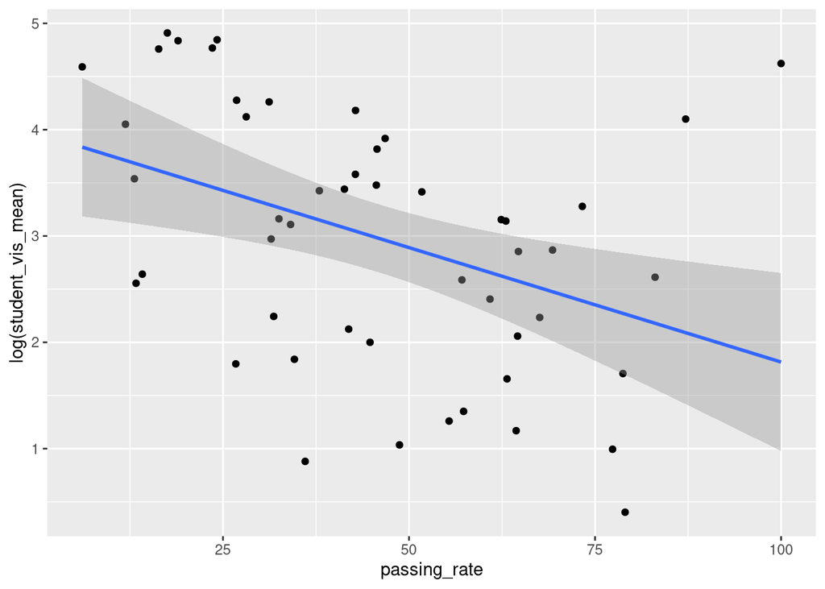

```r
courses %>%
  ggplot(aes(x = passing_rate, y = log(student_vis_mean))) + geom_point() +  geom_smooth(method = "lm")
```

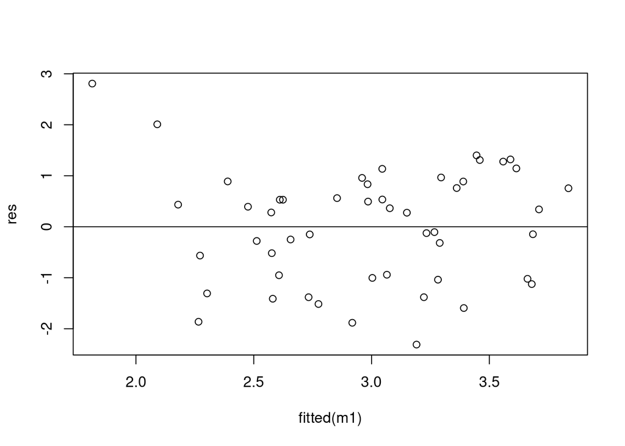

```r
m1 <-  lm(log(student_vis_mean) ~ passing_rate, courses)
res <- resid(m1)
plot(fitted(m1), res)
abline(0,0)
```

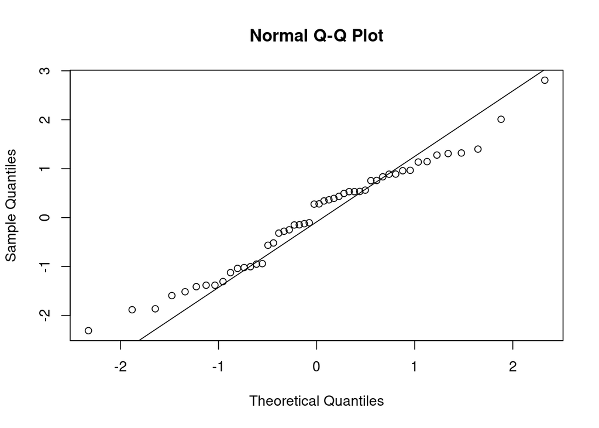

```
## Изменение на 1 пункт в выживаемости курса уменьшает на 1.124 пунктов среднее количество посещений форума.
## Чтобы получить данное значение мы нашли разницу между интерсептом и интерсепт + угол наклона, а полученное значение экспоненциировали
## Это изменение значимо с p = 0
```

```r
qqnorm(res)
qqline(res)
```

## 3. Модераторы и их влияние

### 3.1 Описание переменных и обоснование их выбора

```
## Распределение переменной q_staff_n:
```

```
##
##   0   1   2   3   4   7  10  11  18  24 440
##  39   3   2   2   2   1   1   1   1   1   1
```

```
##
## Распределение переменной ans_staff_n:
```

```
##
##   0   1   2   3   5   6   7  11  12  13  15  17  24  27  28  30  50  56  86 103
##  22   1   2   2   3   1   2   2   1   2   1   1   1   2   2   1   1   1   1   1
## 120 125 222 336
##   1   1   1   1
```

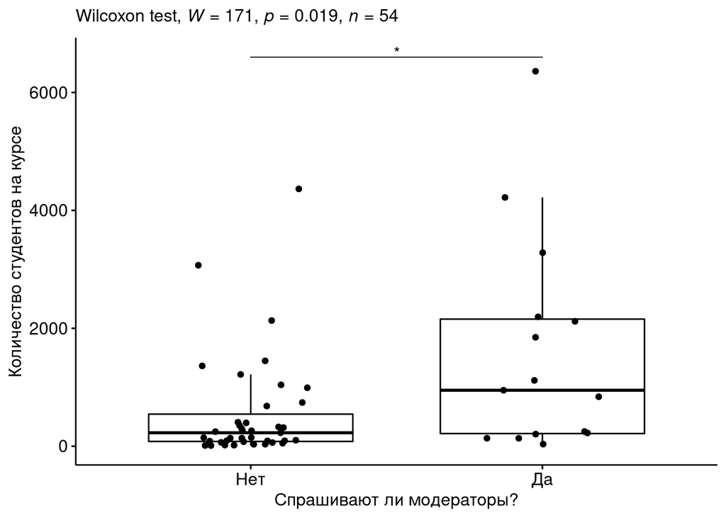

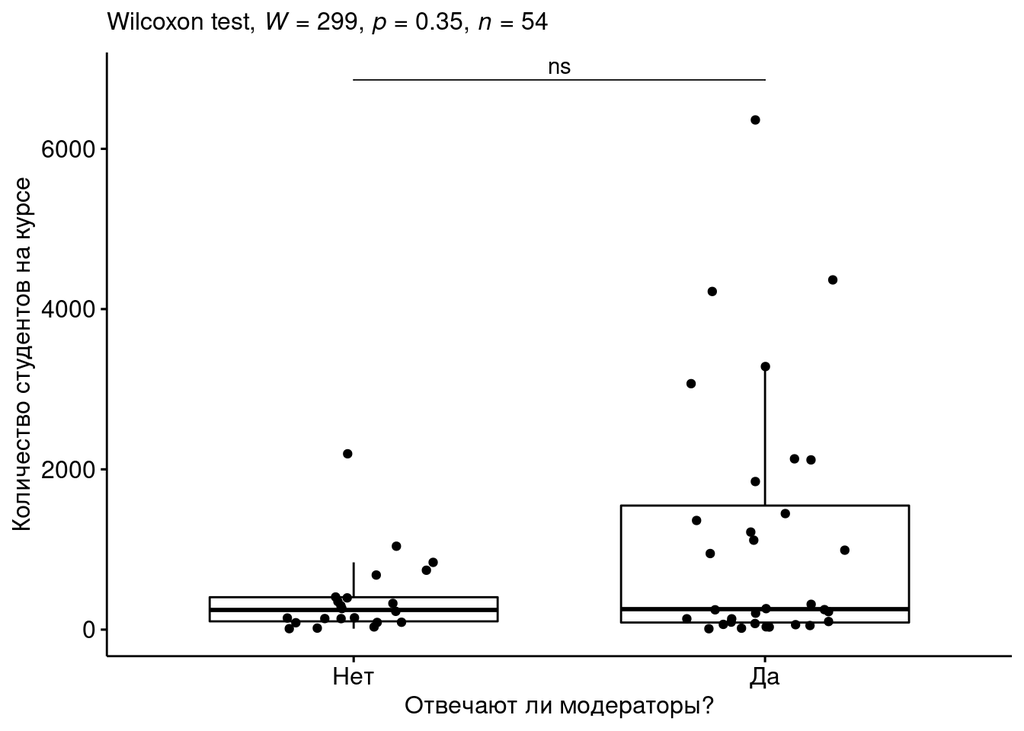

```
## Количество вопросов модераторов коррелирует с количеством студентов записавшихся на курс.
## Поэтому нужно использовать нормализованные переменные - они позволяют избежать влияния спутывающей переменной количество студентов
```

### 3.2 Рассчеты

### 3.2.1 Влияние модераторской активности на вопросы пользователей

```
## У рассматриваемых переменных наблюдается гетероскедастичность, поэтому каждая из них подвергается трансформации с помощью функции log()
## Чтобы вывести из трансформации мы экспоненциируемы коэффициенты
```

```r
m1 <-  lm(log(1+q_learner_n) ~ log(1 + q_staff_n) + log(1 + ans_staff_n), courses)
summary(m1)
```

```
##
## Call:
## lm(formula = log(1 + q_learner_n) ~ log(1 + q_staff_n) + log(1 +
##     ans_staff_n), data = courses)
##
## Residuals:
##     Min      1Q  Median      3Q     Max
## -3.1916 -0.9892 -0.0395  0.8638  3.3675
##
## Coefficients:
##                      Estimate Std. Error t value Pr(>|t|)
## (Intercept)            2.7809     0.2575  10.799 8.79e-15 ***
## log(1 + q_staff_n)    -0.2698     0.1656  -1.630  0.10929
## log(1 + ans_staff_n)   0.2962     0.1071   2.766  0.00788 **
## ---
## Signif. codes:  0 '***' 0.001 '**' 0.01 '*' 0.05 '.' 0.1 ' ' 1
##
## Residual standard error: 1.327 on 51 degrees of freedom
## Multiple R-squared:  0.143,  Adjusted R-squared:  0.1094
## F-statistic: 4.256 on 2 and 51 DF,  p-value: 0.01953
```

```
## Рост количества нормализованных ответов модераторов на 1% увеличит нормализованное количество вопросов пользователей на 1.34%.
```

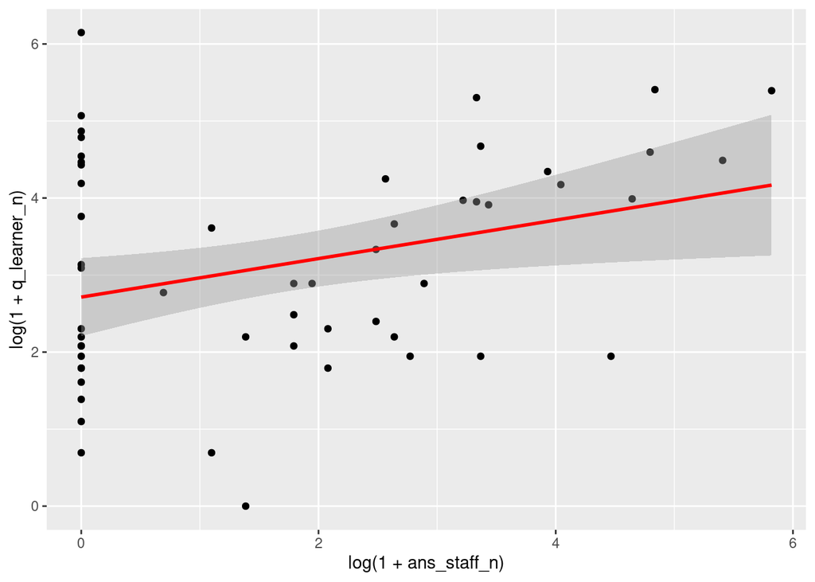

```r
courses %>%
  ggplot(aes(y = log(1 + q_learner_n), x = log(1 + ans_staff_n))) + geom_point() +  geom_smooth(method="glm", color = "red")
```

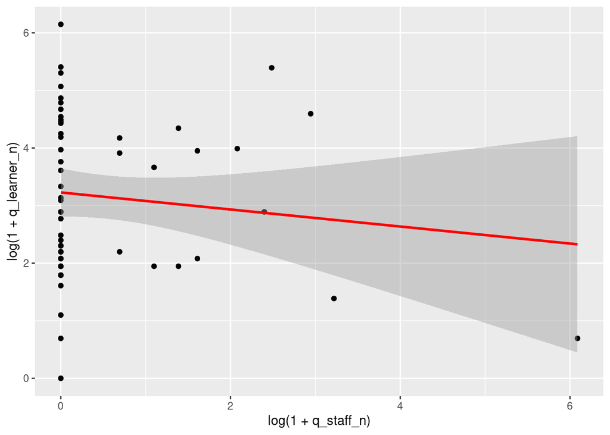

```r
courses %>%
  ggplot(aes(y = log(1+ q_learner_n), x = log(1+ q_staff_n))) + geom_point() +  geom_smooth(method="glm", color = "red")
```

### 3.2.2 Влияние модераторской активности на ответы пользователей

```r
m1 <-  lm(log(ans_learner_n +1) ~ log(1+q_staff_n) + log(1+ ans_staff_n), courses)
summary(m1)
```

```
##
## Call:
## lm(formula = log(ans_learner_n + 1) ~ log(1 + q_staff_n) + log(1 +
##     ans_staff_n), data = courses)
##
## Residuals:
##     Min      1Q  Median      3Q     Max
## -4.4585 -1.0889  0.1800  0.9825  3.5707
##
## Coefficients:
##                      Estimate Std. Error t value Pr(>|t|)
## (Intercept)            3.0613     0.2996  10.219 6.14e-14 ***
## log(1 + q_staff_n)     0.5168     0.1926   2.683   0.0098 **
## log(1 + ans_staff_n)   0.1524     0.1246   1.224   0.2267
## ---
## Signif. codes:  0 '***' 0.001 '**' 0.01 '*' 0.05 '.' 0.1 ' ' 1
##
## Residual standard error: 1.544 on 51 degrees of freedom
## Multiple R-squared:  0.1806, Adjusted R-squared:  0.1485
## F-statistic: 5.621 on 2 and 51 DF,  p-value: 0.006223
```

```
## Рост количества нормализованных вопросов модераторов на 1% увеличит нормализованное количество ответов пользователей на 1.68%.
```

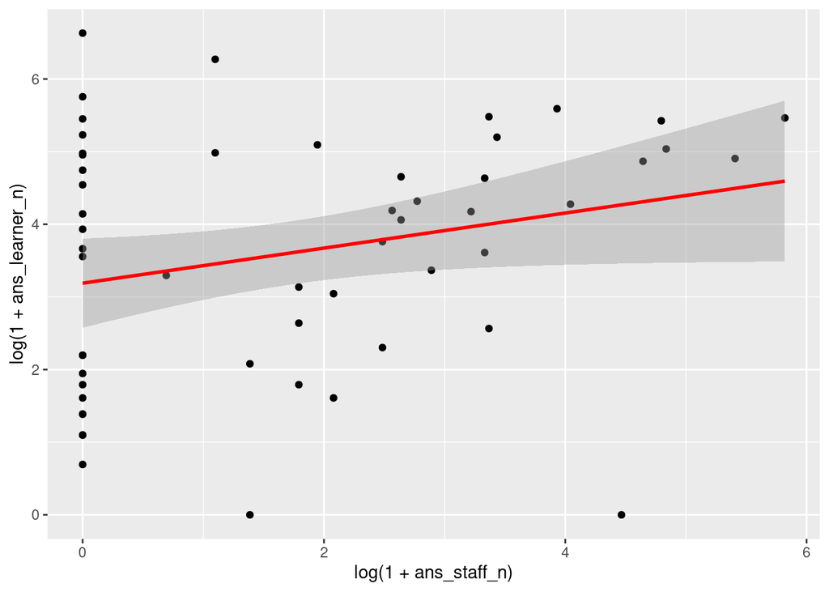

```r
courses %>%
  ggplot(aes(y = log(1 + ans_learner_n), x = log(1+ ans_staff_n))) + geom_point() +  geom_smooth(method="glm", color = "red")
```

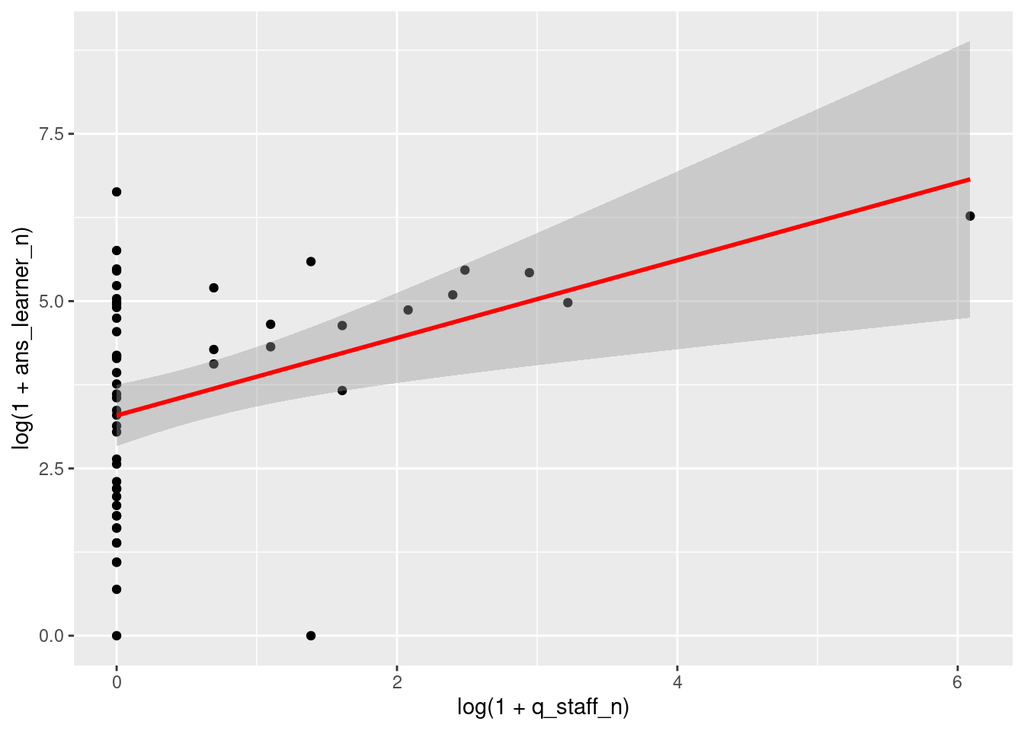

```r
courses %>%
  ggplot(aes(y = log(1+ ans_learner_n), x = log(1+ q_staff_n))) + geom_point() +  geom_smooth(method="glm", color = "red")
```

### 3.2.3 Влияние модераторской активности на посещение форума пользователями

```r
m1 <-  lm(log(student_vis_mean) ~ log(1+q_staff_n) + log(1+ ans_staff_n), courses)
summary(m1)
```

```
##
## Call:
## lm(formula = log(student_vis_mean) ~ log(1 + q_staff_n) + log(1 +
##     ans_staff_n), data = courses)
##
## Residuals:
##     Min      1Q  Median      3Q     Max
## -2.0682 -0.6200 -0.1089  0.6609  2.3753
##
## Coefficients:
##                      Estimate Std. Error t value Pr(>|t|)
## (Intercept)           2.47029    0.21911  11.274  5.8e-15 ***
## log(1 + q_staff_n)   -0.15844    0.13731  -1.154 0.254378
## log(1 + ans_staff_n)  0.35235    0.09179   3.839 0.000368 ***
## ---
## Signif. codes:  0 '***' 0.001 '**' 0.01 '*' 0.05 '.' 0.1 ' ' 1
##
## Residual standard error: 1.081 on 47 degrees of freedom
##   (4 observations deleted due to missingness)
## Multiple R-squared:  0.2409, Adjusted R-squared:  0.2086
## F-statistic: 7.456 on 2 and 47 DF,  p-value: 0.00154
```

[output not shown]

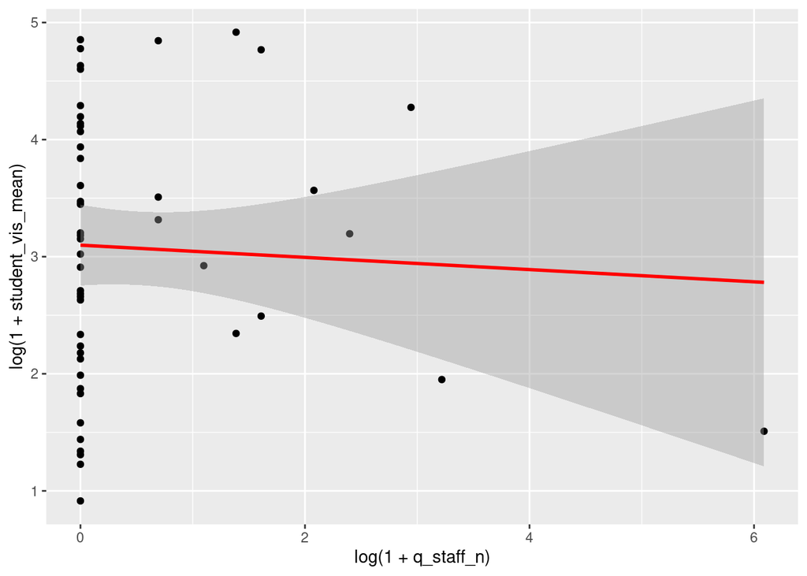

```r
courses %>%
  ggplot(aes(y = log(1 + student_vis_mean), x = log(1+ q_staff_n))) + geom_point() +  geom_smooth(method="glm", color = "red")
```

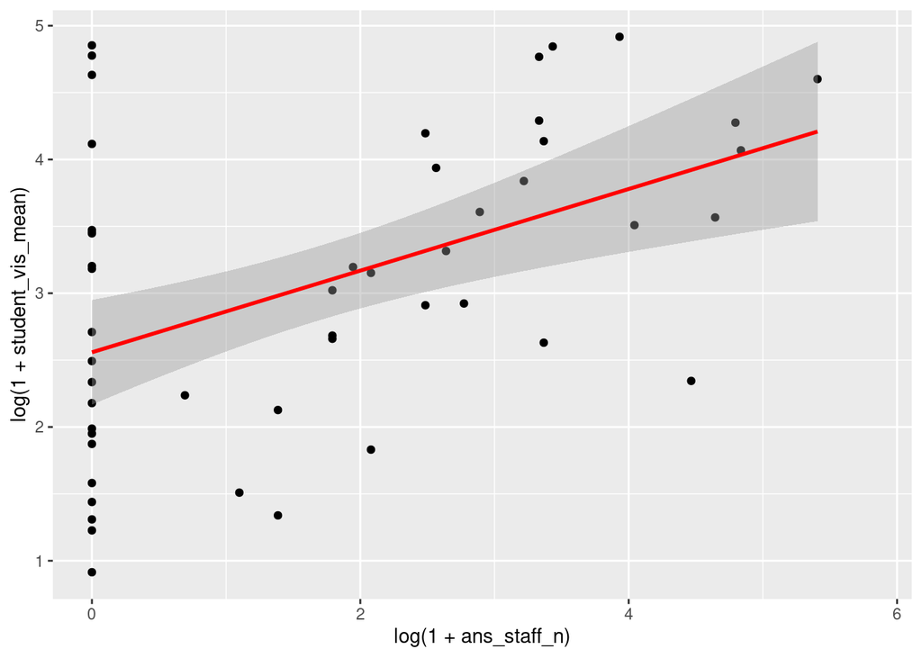

```r
courses %>%
  ggplot(aes(y = log(1 +student_vis_mean), x = log(1 + ans_staff_n))) + geom_point() +  geom_smooth(method="glm", color = "red")
```

## 4. Взаимодействие выживаемости и форумной активности

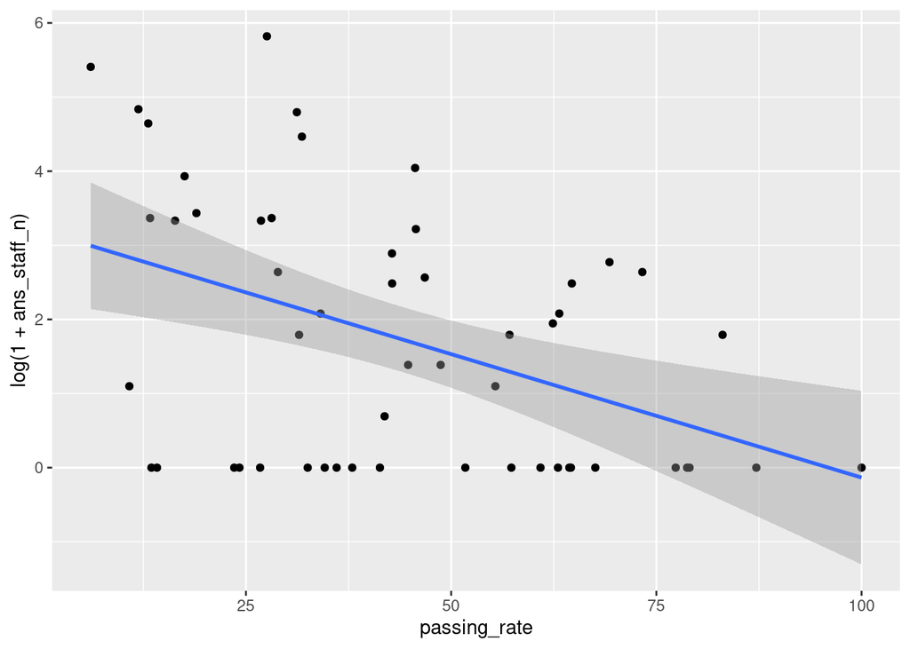

```r
 courses %>%
  ggplot(aes(x = passing_rate, y = log(1 +ans_staff_n))) + geom_point() +  geom_smooth(method = "lm")
```

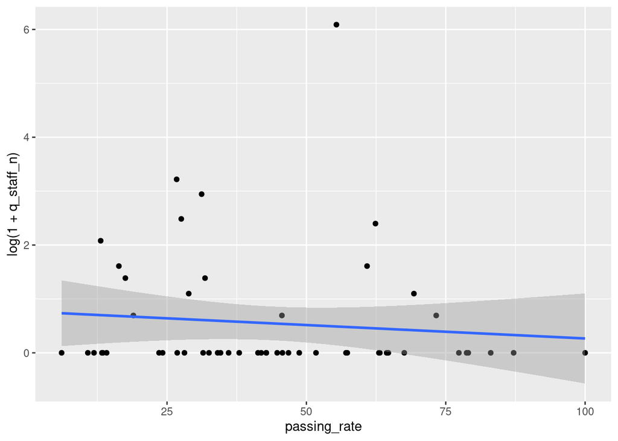

```r
courses %>%
  ggplot(aes(x = passing_rate, y = log(1 +q_staff_n))) + geom_point() +  geom_smooth(method = "lm")
```

```r
m1 <-  lm(log(passing_rate) ~ log(1+q_staff_n) + log(1+ ans_staff_n), courses)
summary(m1)
```

```
##
## Call:
## lm(formula = log(passing_rate) ~ log(1 + q_staff_n) + log(1 +
##     ans_staff_n), data = courses)
##
## Residuals:
##     Min      1Q  Median      3Q     Max
## -1.3220 -0.3834  0.1564  0.4410  0.8335
##
## Coefficients:
##                      Estimate Std. Error t value Pr(>|t|)
## (Intercept)           3.88294    0.11117  34.928  < 2e-16 ***
## log(1 + q_staff_n)    0.03801    0.07147   0.532 0.597133
## log(1 + ans_staff_n) -0.16562    0.04623  -3.583 0.000759 ***
## ---
## Signif. codes:  0 '***' 0.001 '**' 0.01 '*' 0.05 '.' 0.1 ' ' 1
##
## Residual standard error: 0.5729 on 51 degrees of freedom
## Multiple R-squared:  0.2035, Adjusted R-squared:  0.1722
## F-statistic: 6.513 on 2 and 51 DF,  p-value: 0.003026
```

[output not shown]

```r
m1 <-  lm(log(passing_rate) ~ log(1+q_learner_n) + log(1+ ans_learner_n), courses)
summary(m1)
```

```
##
## Call:
## lm(formula = log(passing_rate) ~ log(1 + q_learner_n) + log(1 +
##     ans_learner_n), data = courses)
##
## Residuals:
##     Min      1Q  Median      3Q     Max
## -1.5322 -0.3477  0.1210  0.3381  1.3867
##
## Coefficients:
##                        Estimate Std. Error t value Pr(>|t|)
## (Intercept)             4.29208    0.20111  21.341   <2e-16 ***
## log(1 + q_learner_n)   -0.16870    0.08063  -2.092   0.0414 *
## log(1 + ans_learner_n) -0.04007    0.06777  -0.591   0.5569
## ---
## Signif. codes:  0 '***' 0.001 '**' 0.01 '*' 0.05 '.' 0.1 ' ' 1
##
## Residual standard error: 0.57 on 51 degrees of freedom
## Multiple R-squared:  0.2113, Adjusted R-squared:  0.1804
## F-statistic: 6.832 on 2 and 51 DF,  p-value: 0.00235
```

[output not shown]

## Выводы

Тактические выводы:

[output not shown]

Стратегические выводы:

```
1. Посещение форума позволяет нам судить о сложности курса. Чем сложнее проходить курс, тем чаще студенты заходят на форум.
2. Задания по программированию, по математике, пир-ревью задания - сложные и вынуждают пользователей заходить на форум
3. Активность модераторов влияет на форумную активность студентов
  - если модераторы отвечают на вопросы, то это увеличивает посещение форума курса и подстегивает пользователей задавать больше вопросов
  - если модераторы задают вопросы, то это подстегивает пользователей отвечать на вопросы.
4. Чем сложнее курс тем чаще студенты задают вопросы, а модераторы отвечают на них.
```

```r
m <- glm(data = courses, is_prog_b ~ student_vis_mean, family = "binomial")
summary(m)
```

```
##
## Call:
## glm(formula = is_prog_b ~ student_vis_mean, family = "binomial",
##     data = courses)
##
## Deviance Residuals:
##     Min       1Q   Median       3Q      Max
## -1.1739  -0.5667  -0.4737  -0.4410   2.1186
##
## Coefficients:
##                   Estimate Std. Error z value Pr(>|z|)
## (Intercept)      -2.335143   0.601932  -3.879 0.000105 ***
## student_vis_mean  0.018295   0.008834   2.071 0.038364 *
## ---
## Signif. codes:  0 '***' 0.001 '**' 0.01 '*' 0.05 '.' 0.1 ' ' 1
##
## (Dispersion parameter for binomial family taken to be 1)
##
##     Null deviance: 47.139  on 49  degrees of freedom
## Residual deviance: 42.819  on 48  degrees of freedom
##   (4 observations deleted due to missingness)
## AIC: 46.819
##
## Number of Fisher Scoring iterations: 4
```

```r
invlogit(m$coefficients[1])
```

```
## (Intercept)
##  0.08825396
```

```r
invlogit(m$coefficients[1] + m$coefficients[2])
```

```
## (Intercept)
##  0.08973721
```